# PNAD Contínua — Survey Analysis in R

Descriptive Analysis, Survey Weights, and Regression Models

Teresa De Bastiani

abril 05, 2026

## Overview

This document presents a three-part analysis of Brazil’s national household survey (**PNAD Contínua**, 4th quarter 2023) using microdata downloaded directly from IBGE via the `PNADcIBGE` package.

The analysis follows a methodological progression:

1. **Descriptive analysis** — distributions, cross-tabulations, and visualization
2. **Survey weights** — why unweighted estimates are biased and how to correct them
3. **Regression models** — OLS and logistic models with correct inference for complex survey data

All categorical variables use the labels returned by `get_pnadc(labels = TRUE)`, which applies the official IBGE data dictionary. No numeric codes are used.

## 1. Setup

```r
library(PNADcIBGE)
library(tidyverse)
library(survey)
library(srvyr)
library(broom)

options(survey.lonely.psu = "adjust")

theme_pnadc <- function() {
  theme_minimal(base_size = 12) +
    theme(
      plot.title       = element_text(face = "bold", size = 13),
      plot.subtitle    = element_text(color = "grey40", size = 10),
      plot.caption     = element_text(color = "grey55", size = 8),
      axis.title       = element_text(size = 10),
      legend.position  = "bottom",
      panel.grid.minor = element_blank()
    )
}

PALETTE <- c(
  "main"   = "#2E86AB",
  "accent" = "#E24B4A",
  "mid"    = "#F18F01",
  "soft"   = "#B0C4DE",
  "green"  = "#4CAF50"
)
```

## 2. Data download

PNAD Contínua microdata is downloaded directly from IBGE servers using `get_pnadc()`. Setting `labels = TRUE` applies the official data dictionary to all categorical variables, returning them as labeled factors. This eliminates the need for manual numeric recoding and makes the code robust to dictionary changes across survey editions.

```r
vars_needed <- c(
  "UF", "UPA", "Estrato", "V1028",
  "V2007", "V2009", "V2010",
  "VD3005", "VD4001", "VD4002", "VD4009", "VD4020"
)

pnadc_design <- get_pnadc(
  year     = 2023,
  quarter  = 4,
  vars     = vars_needed,
  labels   = TRUE,
  deflator = FALSE,
  design   = TRUE
)

cat(sprintf("Download complete: %d respondents\n", nrow(pnadc_design$variables)))
```

```
Download complete: 473206 respondents
```

## 3. Label inspection

Before recoding any variable, we inspect the labels returned by the IBGE dictionary. The exact strings shown here are what must be used in all `case_when()` calls below.

```r
cat("V2007 (Gender):\n");      print(levels(pnadc_design$variables$V2007))
```

```
V2007 (Gender):
```

```
[1] "Homem"  "Mulher"
```

```r
cat("V2010 (Race):\n");        print(levels(pnadc_design$variables$V2010))
```

```
V2010 (Race):
```

```
[1] "Branca"   "Preta"    "Amarela"  "Parda"    "Indígena" "Ignorado"
```

```r
cat("VD3005 (Schooling):\n");  print(levels(pnadc_design$variables$VD3005))
```

```
VD3005 (Schooling):
```

```
 [1] "Sem instrução e menos de 1 ano de estudo"
 [2] "1 ano de estudo"
 [3] "2 anos de estudo"
 [4] "3 anos de estudo"
 [5] "4 anos de estudo"
 [6] "5 anos de estudo"
 [7] "6 anos de estudo"
 [8] "7 anos de estudo"
 [9] "8 anos de estudo"
[10] "9 anos de estudo"
[11] "10 anos de estudo"
[12] "11 anos de estudo"
[13] "12 anos de estudo"
[14] "13 anos de estudo"
[15] "14 anos de estudo"
[16] "15 anos de estudo"
[17] "16 anos ou mais de estudo"
```

```r
cat("VD4001 (Labor force):\n"); print(levels(pnadc_design$variables$VD4001))
```

```
VD4001 (Labor force):
```

```
[1] "Pessoas na força de trabalho"      "Pessoas fora da força de trabalho"
```

```r
cat("VD4002 (Employment):\n"); print(levels(pnadc_design$variables$VD4002))
```

```
VD4002 (Employment):
```

```
[1] "Pessoas ocupadas"    "Pessoas desocupadas"
```

```r
cat("VD4009 (Job type):\n");   print(levels(pnadc_design$variables$VD4009))
```

```
VD4009 (Job type):
```

```
 [1] "Empregado no setor privado com carteira de trabalho assinada"
 [2] "Empregado no setor privado sem carteira de trabalho assinada"
 [3] "Trabalhador doméstico com carteira de trabalho assinada"
 [4] "Trabalhador doméstico sem carteira de trabalho assinada"
 [5] "Empregado no setor público com carteira de trabalho assinada"
 [6] "Empregado no setor público sem carteira de trabalho assinada"
 [7] "Militar e servidor estatutário"
 [8] "Empregador"
 [9] "Conta-própria"
[10] "Trabalhador familiar auxiliar"
```

## 4. Variable recoding

All recoding is done inside the design object using `update()`. Extracting the data, recoding, and rebuilding the design would break the sample design structure.

```r
pnadc_design <- update(pnadc_design,

  education = factor(case_when(
    VD3005 == "Sem instrução e menos de 1 ano de estudo" ~ "No schooling",
    VD3005 %in% c(
      "1 ano de estudo","2 anos de estudo","3 anos de estudo","4 anos de estudo"
    ) ~ "Primary incomplete",
    VD3005 %in% c(
      "5 anos de estudo","6 anos de estudo","7 anos de estudo","8 anos de estudo"
    ) ~ "Primary complete",
    VD3005 %in% c(
      "9 anos de estudo","10 anos de estudo","11 anos de estudo"
    ) ~ "Secondary",
    VD3005 %in% c(
      "12 anos de estudo","13 anos de estudo","14 anos de estudo",
      "15 anos de estudo","16 anos ou mais de estudo"
    ) ~ "Higher education",
    TRUE ~ NA_character_
  ), levels = c("No schooling","Primary incomplete","Primary complete",
                "Secondary","Higher education")),

  race = factor(case_when(
    V2010 == "Branca"   ~ "White",
    V2010 == "Preta"    ~ "Black",
    V2010 == "Parda"    ~ "Brown (Pardo)",
    V2010 == "Amarela"  ~ "Asian",
    V2010 == "Indígena" ~ "Indigenous",
    TRUE                ~ NA_character_
  ), levels = c("White","Black","Brown (Pardo)","Asian","Indigenous")),

  macro_region = factor(case_when(
    UF %in% c("Rondônia","Acre","Amazonas","Roraima","Pará","Amapá","Tocantins") ~ "North",
    UF %in% c("Maranhão","Piauí","Ceará","Rio Grande do Norte","Paraíba",
              "Pernambuco","Alagoas","Sergipe","Bahia") ~ "Northeast",
    UF %in% c("Minas Gerais","Espírito Santo","Rio de Janeiro","São Paulo") ~ "Southeast",
    UF %in% c("Paraná","Santa Catarina","Rio Grande do Sul") ~ "South",
    UF %in% c("Mato Grosso do Sul","Mato Grosso","Goiás","Distrito Federal") ~ "Center-West",
    TRUE ~ NA_character_
  ), levels = c("Southeast","North","Northeast","South","Center-West")),

  age    = as.numeric(V2009),
  age_sq = as.numeric(V2009)^2,

  log_income = ifelse(!is.na(VD4020) & VD4020 > 0, log(VD4020), NA_real_),

  in_pea = !is.na(VD4001) & VD4001 == "Pessoas na força de trabalho",

  employed = case_when(
    VD4002 == "Pessoas ocupadas"    ~ 1L,
    VD4002 == "Pessoas desocupadas" ~ 0L,
    TRUE ~ NA_integer_
  )
)

employed_design <- subset(pnadc_design, employed == 1L & !is.na(log_income))
pea_design      <- subset(pnadc_design, in_pea == TRUE & !is.na(employed))

# Raw data for descriptive plots
pnadc <- pnadc_design$variables

cat(sprintf("Employed with income: %d\nPEA: %d\n",
            nrow(employed_design$variables),
            nrow(pea_design$variables)))
```

```
Employed with income: 195572
PEA: 221158
```

## 5. Descriptive analysis

### 5.1 Income distribution by gender

The distribution of log monthly income for employed workers shows a clear rightward shift for men — reflecting a persistent gender income gap across the entire distribution, not just at the mean.

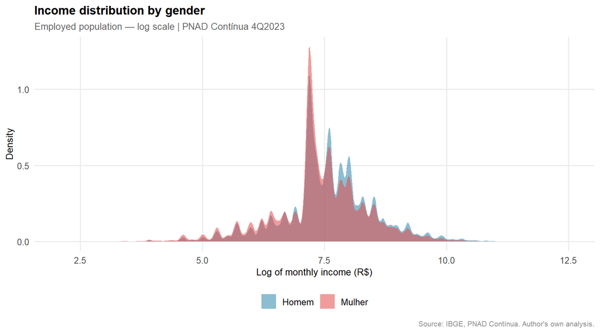

Income distribution by gender (log scale)

```r
pnadc |>
  filter(employed == 1L, !is.na(log_income), !is.na(V2007)) |>
  mutate(V2007 = as.character(V2007)) |>
  ggplot(aes(x = log_income, fill = V2007)) +
  geom_density(alpha = 0.55, color = NA) +
  scale_fill_manual(values = c("Homem" = unname(PALETTE["main"]),
                               "Mulher" = unname(PALETTE["accent"]))) +
  labs(
    title   = "Income distribution by gender",
    subtitle = "Employed population — log scale | PNAD Contínua 4Q2023",
    x = "Log of monthly income (R$)", y = "Density", fill = NULL,
    caption = "Source: IBGE, PNAD Contínua. Author's own analysis."
  ) +
  theme_pnadc()
```

### 5.2 Mean income by education level

Income increases sharply with education. Workers with higher education earn more than twice the mean income of those with primary complete education.

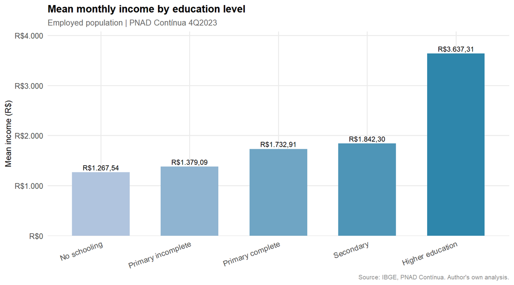

Mean income by education level

```r
pnadc |>
  filter(employed == 1L, !is.na(VD4020), VD4020 > 0, !is.na(education)) |>
  group_by(education) |>
  summarise(mean_income = mean(VD4020), .groups = "drop") |>
  ggplot(aes(x = education, y = mean_income, fill = education)) +
  geom_col(width = 0.65, show.legend = FALSE) +
  geom_text(aes(label = scales::dollar(mean_income, prefix = "R$",
                                        big.mark = ".", decimal.mark = ",")),
            vjust = -0.4, size = 3.2) +
  scale_fill_manual(values = colorRampPalette(c(PALETTE["soft"], PALETTE["main"]))(5)) +
  scale_y_continuous(
    labels = scales::dollar_format(prefix = "R$", big.mark = ".", decimal.mark = ","),
    expand = expansion(mult = c(0, 0.12))
  ) +
  labs(
    title    = "Mean monthly income by education level",
    subtitle = "Employed population | PNAD Contínua 4Q2023",
    x = NULL, y = "Mean income (R$)",
    caption  = "Source: IBGE, PNAD Contínua. Author's own analysis."
  ) +
  theme_pnadc() +
  theme(axis.text.x = element_text(angle = 20, hjust = 1))
```

### 5.3 Mean income by race and gender

The racial income gap is substantial and consistent across genders. White workers earn more than Black and Brown workers in every gender group.

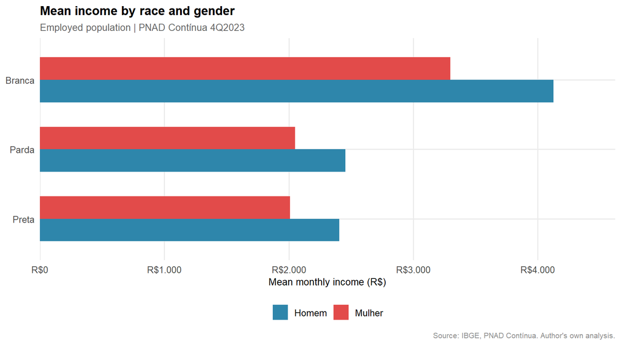

Mean income by race and gender

```r
pnadc |>
  filter(employed == 1L, !is.na(VD4020), VD4020 > 0,
         !is.na(V2010), !is.na(V2007),
         V2010 %in% c("Branca","Preta","Parda")) |>
  group_by(V2010, V2007) |>
  summarise(mean_income = mean(VD4020), .groups = "drop") |>
  mutate(V2007 = as.character(V2007), V2010 = as.character(V2010)) |>
  ggplot(aes(x = reorder(V2010, mean_income), y = mean_income, fill = V2007)) +
  geom_col(position = "dodge", width = 0.65) +
  scale_fill_manual(values = c("Homem" = unname(PALETTE["main"]),
                               "Mulher" = unname(PALETTE["accent"]))) +
  scale_y_continuous(
    labels = scales::dollar_format(prefix = "R$", big.mark = ".", decimal.mark = ","),
    expand = expansion(mult = c(0, 0.12))
  ) +
  coord_flip() +
  labs(
    title    = "Mean income by race and gender",
    subtitle = "Employed population | PNAD Contínua 4Q2023",
    x = NULL, y = "Mean monthly income (R$)", fill = NULL,
    caption  = "Source: IBGE, PNAD Contínua. Author's own analysis."
  ) +
  theme_pnadc()
```

### 5.4 Mean income by macro-region

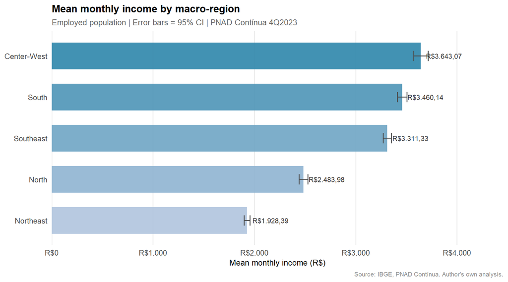

Mean income by macro-region with 95% CI

```r
region_summary <- pnadc |>
  filter(employed == 1L, !is.na(VD4020), VD4020 > 0, !is.na(macro_region)) |>
  group_by(macro_region) |>
  summarise(
    mean_income = mean(VD4020),
    se          = sd(VD4020) / sqrt(n()),
    ci_lower    = mean_income - 1.96 * se,
    ci_upper    = mean_income + 1.96 * se,
    .groups     = "drop"
  )

region_summary |>
  ggplot(aes(x = reorder(macro_region, mean_income), y = mean_income,
             fill = reorder(macro_region, mean_income))) +
  geom_col(width = 0.65, alpha = 0.9, show.legend = FALSE) +
  geom_errorbar(aes(ymin = ci_lower, ymax = ci_upper),
                width = 0.25, color = "grey30", linewidth = 0.7) +
  geom_text(aes(label = scales::dollar(mean_income, prefix = "R$",
                                        big.mark = ".", decimal.mark = ",")),
            hjust = -0.15, size = 3.2, color = "grey20") +
  scale_fill_manual(values = colorRampPalette(c(PALETTE["soft"], PALETTE["main"]))(5)) +
  scale_y_continuous(
    labels = scales::dollar_format(prefix = "R$", big.mark = ".", decimal.mark = ","),
    expand = expansion(mult = c(0, 0.20))
  ) +
  coord_flip() +
  labs(
    title    = "Mean monthly income by macro-region",
    subtitle = "Employed population | Error bars = 95% CI | PNAD Contínua 4Q2023",
    x = NULL, y = "Mean monthly income (R$)",
    caption  = "Source: IBGE, PNAD Contínua. Author's own analysis."
  ) +
  theme_pnadc() +
  theme(panel.grid.major.y = element_blank())
```

## 6. Survey weights and complex sample design

PNAD Contínua uses a complex probability sample — it is not a simple random sample. Ignoring the sample design leads to biased estimates and underestimated standard errors.

Every estimate must account for:

- **Sampling weight** (`V1028`): how many people each respondent represents
- **Stratum** (`Estrato`): groups within which sampling was independent
- **PSU** (`UPA`): primary sampling unit (cluster)

### 6.1 Weighted vs. unweighted comparison

```r
fmt_brl <- function(x) format(round(x, 2), big.mark = ".", decimal.mark = ",", nsmall = 2)

naive_mean   <- mean(employed_design$variables$VD4020, na.rm = TRUE)
weighted_est <- svymean(~VD4020, employed_design, na.rm = TRUE)
ci           <- confint(weighted_est)

cat(sprintf("  Unweighted mean: R$ %s\n", fmt_brl(naive_mean)))
```

```
  Unweighted mean: R$ 2.899,18
```

```r
cat(sprintf("  Weighted mean:   R$ %s\n", fmt_brl(coef(weighted_est))))
```

```
  Weighted mean:   R$ 3.165,72
```

```r
cat(sprintf("  SE (weighted):   R$ %s\n", fmt_brl(SE(weighted_est))))
```

```
  SE (weighted):   R$ 27,78
```

```r
cat(sprintf("  95%% CI: R$ %s to R$ %s\n", fmt_brl(ci[1]), fmt_brl(ci[2])))
```

```
  95% CI: R$ 3.111,27 to R$ 3.220,18
```

### 6.2 Weighted mean income by education

```r
svyby(~VD4020, ~education, employed_design, svymean, na.rm = TRUE) |>
  as_tibble() |>
  set_names(c("education", "mean_income", "se")) |>
  mutate(
    ci_lower = mean_income - 1.96 * se,
    ci_upper = mean_income + 1.96 * se,
    cv_pct   = round(se / mean_income * 100, 1)
  ) |>
  arrange(desc(mean_income))
```

| education | mean_income | se | ci_lower | ci_upper | cv_pct |
| --- | --- | --- | --- | --- | --- |
| Higher education | 3847.224 | 36.42346 | 3775.834 | 3918.614 | 0.9 |
| Secondary | 1890.771 | 15.30168 | 1860.780 | 1920.763 | 0.8 |
| Primary complete | 1767.179 | 16.09472 | 1735.633 | 1798.725 | 0.9 |
| Primary incomplete | 1458.175 | 20.92126 | 1417.169 | 1499.180 | 1.4 |
| No schooling | 1412.034 | 39.83442 | 1333.959 | 1490.110 | 2.8 |

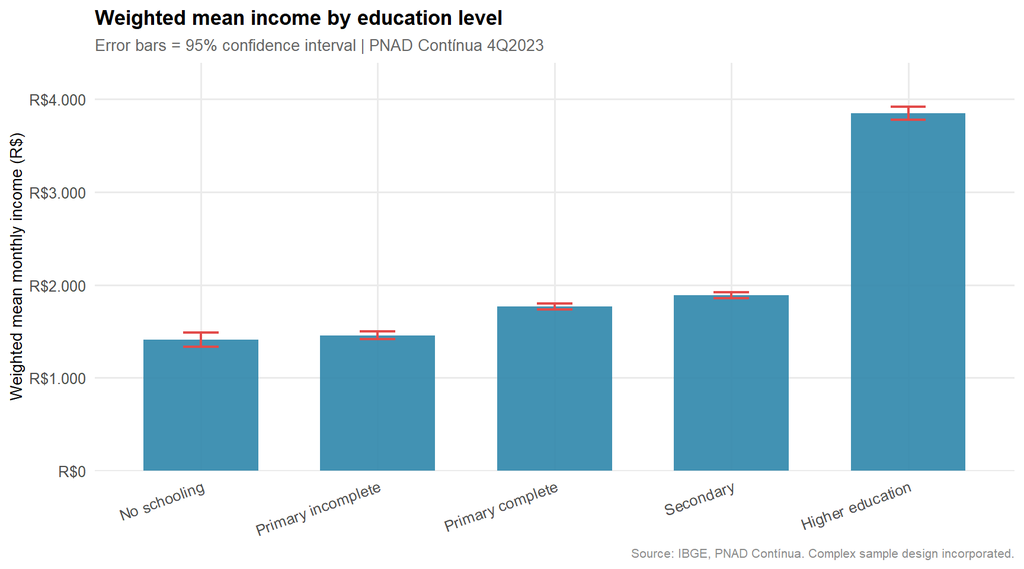

Weighted mean income by education with 95% CI

```r
income_edu <- svyby(~VD4020, ~education, employed_design, svymean, na.rm = TRUE) |>
  as_tibble() |>
  set_names(c("education", "mean_income", "se")) |>
  mutate(
    ci_lower = mean_income - 1.96 * se,
    ci_upper = mean_income + 1.96 * se
  ) |>
  filter(!is.na(education))

ggplot(income_edu,
       aes(x = factor(education,
                      levels = c("No schooling","Primary incomplete",
                                 "Primary complete","Secondary","Higher education")),
           y = mean_income)) +
  geom_col(fill = unname(PALETTE["main"]), width = 0.65, alpha = 0.9) +
  geom_errorbar(aes(ymin = ci_lower, ymax = ci_upper),
                width = 0.2, color = unname(PALETTE["accent"]), linewidth = 0.8) +
  scale_y_continuous(
    labels = scales::dollar_format(prefix = "R$", big.mark = ".", decimal.mark = ","),
    expand = expansion(mult = c(0, 0.12))
  ) +
  labs(
    title    = "Weighted mean income by education level",
    subtitle = "Error bars = 95% confidence interval | PNAD Contínua 4Q2023",
    x = NULL, y = "Weighted mean monthly income (R$)",
    caption  = "Source: IBGE, PNAD Contínua. Complex sample design incorporated."
  ) +
  theme_pnadc() +
  theme(axis.text.x = element_text(angle = 20, hjust = 1))
```

### 6.3 Design effect (DEFF)

```r
deff_df <- svyby(~VD4020, ~macro_region, employed_design,
                 svymean, na.rm = TRUE, deff = TRUE) |>
  as_tibble() |>
  set_names(c("macro_region", "mean_income", "se", "deff")) |>
  mutate(cv_pct = round(se / mean_income * 100, 1)) |>
  select(macro_region, mean_income, se, cv_pct, deff)

deff_df
```

| macro_region | mean_income | se | cv_pct | deff |
| --- | --- | --- | --- | --- |
| Southeast | 3587.092 | 55.81313 | 1.6 | 6.178256 |
| North | 2529.011 | 50.47692 | 2.0 | 5.031213 |
| Northeast | 2101.137 | 35.35651 | 1.7 | 5.274191 |
| South | 3454.891 | 35.87985 | 1.0 | 2.280444 |
| Center-West | 3665.608 | 71.55197 | 2.0 | 3.919709 |

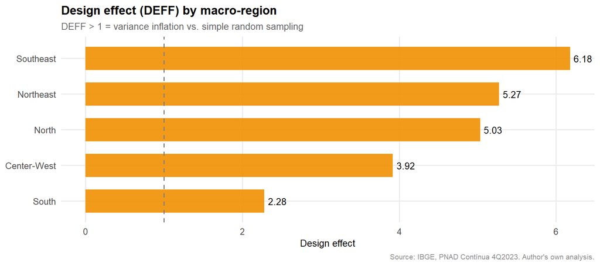

Design effect by macro-region

```r
deff_df |>
  ggplot(aes(x = reorder(macro_region, deff), y = deff)) +
  geom_col(fill = unname(PALETTE["mid"]), width = 0.65, alpha = 0.9) +
  geom_hline(yintercept = 1, linetype = "dashed", color = "grey50") +
  geom_text(aes(label = round(deff, 2)), hjust = -0.2, size = 3.5) +
  coord_flip() +
  labs(
    title    = "Design effect (DEFF) by macro-region",
    subtitle = "DEFF > 1 = variance inflation vs. simple random sampling",
    x = NULL, y = "Design effect",
    caption  = "Source: IBGE, PNAD Contínua 4Q2023. Author's own analysis."
  ) +
  theme_pnadc()
```

### 6.4 Weighted cross-tabulation: employment by gender

```r
as_survey_rep(pnadc_design) |>
  filter(!is.na(employed), !is.na(V2007)) |>
  group_by(V2007, as.character(employed)) |>
  summarise(pct = survey_mean() * 100, .groups = "drop") |>
  mutate(across(where(is.numeric), \(x) round(x, 1)))
```

| V2007 | as.character(employed) | pct | pct_se |
| --- | --- | --- | --- |
| Homem | 0 | 6.0 | 0.1 |
| Homem | 1 | 94.0 | 0.1 |
| Mulher | 0 | 9.2 | 0.1 |
| Mulher | 1 | 90.8 | 0.1 |

## 7. Regression models

Both models use `svyglm()`, which correctly incorporates the complex sample design into the estimation — producing valid standard errors, confidence intervals, and p-values for population-level inference.

### 7.1 OLS — determinants of log income

**Model:** `log(income) ~ education + gender + race + age + age² + macro_region`

Coefficients on the log scale can be interpreted as approximate percentage changes in income: `(exp(coef) - 1) × 100`.

Reference categories: Secondary (education), Homem (gender), White (race), Southeast (region).

```r
# Relevel for regression reference categories
pnadc_design <- update(pnadc_design,
  education    = relevel(education, ref = "Secondary"),
  race         = relevel(race,      ref = "White"),
  macro_region = relevel(macro_region, ref = "Southeast")
)
employed_design <- subset(pnadc_design, employed == 1L & !is.na(log_income))

model_ols <- svyglm(
  log_income ~ education + V2007 + race + age + age_sq + macro_region,
  design = employed_design,
  family = gaussian()
)

tidy_ols <- tidy(model_ols, conf.int = TRUE) |>
  filter(term != "(Intercept)") |>
  mutate(
    pct_effect = round((exp(estimate) - 1) * 100, 2),
    sig = case_when(
      p.value < 0.001 ~ "***",
      p.value < 0.01  ~ "**",
      p.value < 0.05  ~ "*",
      p.value < 0.1   ~ ".",
      TRUE             ~ ""
    )
  )

tidy_ols |>
  select(term, estimate, std.error, pct_effect, p.value, sig) |>
  mutate(across(where(is.numeric), \(x) round(x, 4)))
```

| term | estimate | std.error | pct_effect | p.value | sig |
| --- | --- | --- | --- | --- | --- |
| educationNo schooling | -0.4388 | 0.0215 | -35.52 | 0.0000 | *** |
| educationPrimary incomplete | -0.4371 | 0.0131 | -35.41 | 0.0000 | *** |
| educationPrimary complete | -0.2058 | 0.0084 | -18.60 | 0.0000 | *** |
| educationHigher education | 0.5313 | 0.0073 | 70.12 | 0.0000 | *** |
| V2007Mulher | -0.3277 | 0.0044 | -27.94 | 0.0000 | *** |
| raceBlack | -0.2212 | 0.0090 | -19.84 | 0.0000 | *** |
| raceBrown (Pardo) | -0.2202 | 0.0067 | -19.76 | 0.0000 | *** |
| raceAsian | 0.0494 | 0.0360 | 5.07 | 0.1719 |  |
| raceIndigenous | -0.3193 | 0.0382 | -27.34 | 0.0000 | *** |
| age | 0.0688 | 0.0013 | 7.12 | 0.0000 | *** |

[output cut: 5 more lines]

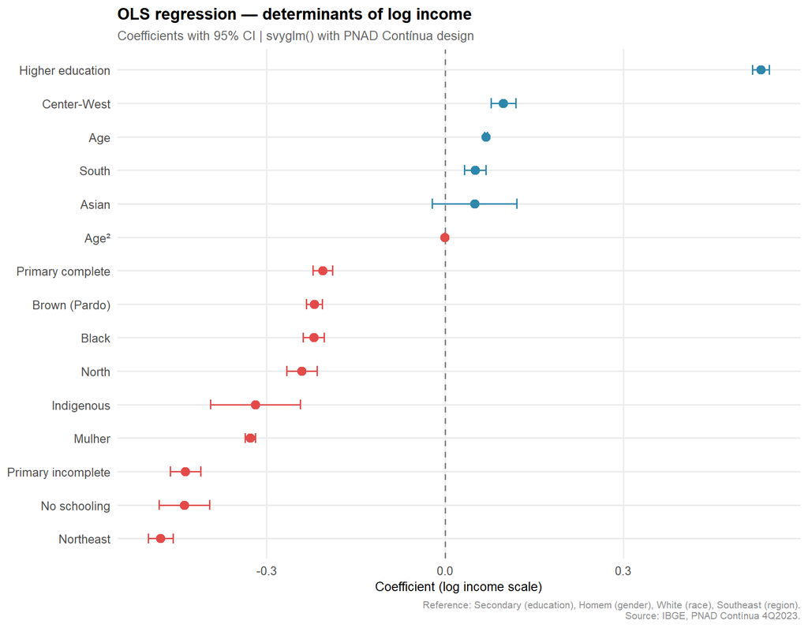

OLS coefficient plot

```r
tidy_ols |>
  mutate(
    direction  = ifelse(estimate > 0, "positive", "negative"),
    term_clean = term |>
      str_remove("^education|^V2007|^race|^macro_region") |>
      str_replace("age_sq", "Age²") |>
      str_replace("^age$", "Age")
  ) |>
  ggplot(aes(x = estimate, y = reorder(term_clean, estimate), color = direction)) +
  geom_vline(xintercept = 0, linetype = "dashed", color = "grey50") +
  geom_point(size = 3) +
  geom_errorbar(aes(xmin = conf.low, xmax = conf.high),
                width = 0.3, orientation = "y") +
  scale_color_manual(
    values = c("positive" = unname(PALETTE["main"]),
               "negative" = unname(PALETTE["accent"])),
    guide  = "none"
  ) +
  labs(
    title    = "OLS regression — determinants of log income",
    subtitle = "Coefficients with 95% CI | svyglm() with PNAD Contínua design",
    x = "Coefficient (log income scale)", y = NULL,
    caption  = "Reference: Secondary (education), Homem (gender), White (race), Southeast (region).\nSource: IBGE, PNAD Contínua 4Q2023."
  ) +
  theme_pnadc()
```

**Key findings:**

- Workers with **higher education** earn **70% more** than those with secondary education, controlling for all other factors
- **Women** earn **28% less** than men with equivalent education, race, age, and region
- **Black** and **Brown (Pardo)** workers earn approximately **20% less** than White workers
- **Northeast** workers earn **38% less** than Southeast workers

### 7.2 Logistic — probability of employment in the PEA

**Model:** `P(employed = 1) ~ education + gender + race + age + age² + macro_region`

The model is restricted to the **economically active population** (PEA) — people who are either employed or actively seeking employment. This is the correct population for modeling employment probability. Including inactive people (retired, students, homemakers) would dilute the relationship between predictors and employment status.

Results are reported as **odds ratios** (OR > 1 = higher odds of employment).

```r
pea_design <- subset(pnadc_design, in_pea == TRUE & !is.na(employed))

model_logit <- svyglm(
  employed ~ education + V2007 + race + age + age_sq + macro_region,
  design = pea_design,
  family = quasibinomial()
)

tidy_logit <- tidy(model_logit, conf.int = TRUE, exponentiate = TRUE) |>
  filter(term != "(Intercept)") |>
  mutate(
    sig = case_when(
      p.value < 0.001 ~ "***",
      p.value < 0.01  ~ "**",
      p.value < 0.05  ~ "*",
      p.value < 0.1   ~ ".",
      TRUE             ~ ""
    )
  )

tidy_logit |>
  rename(odds_ratio = estimate, or_ci_low = conf.low, or_ci_high = conf.high) |>
  mutate(across(where(is.numeric), \(x) round(x, 4)))
```

| term | odds_ratio | std.error | statistic | p.value | or_ci_low | or_ci_high | sig |
| --- | --- | --- | --- | --- | --- | --- | --- |
| educationNo schooling | 1.0838 | 0.0813 | 0.9907 | 0.3232 | 0.9233 | 1.2723 |  |
| educationPrimary incomplete | 0.9001 | 0.0579 | -1.8177 | 0.0707 | 0.8030 | 1.0090 | . |
| educationPrimary complete | 0.9337 | 0.0377 | -1.8188 | 0.0706 | 0.8668 | 1.0058 | . |
| educationHigher education | 1.5671 | 0.0301 | 14.9254 | 0.0000 | 1.4767 | 1.6630 | *** |
| V2007Mulher | 0.5711 | 0.0232 | -24.1814 | 0.0000 | 0.5456 | 0.5978 | *** |
| raceBlack | 0.7793 | 0.0410 | -6.0850 | 0.0000 | 0.7187 | 0.8449 | *** |
| raceBrown (Pardo) | 0.8521 | 0.0314 | -5.1029 | 0.0000 | 0.8010 | 0.9065 | *** |
| raceAsian | 1.1005 | 0.1428 | 0.6710 | 0.5031 | 0.8304 | 1.4586 |  |
| raceIndigenous | 0.9760 | 0.1708 | -0.1424 | 0.8870 | 0.6967 | 1.3672 |  |
| age | 1.1430 | 0.0044 | 30.4903 | 0.0000 | 1.1332 | 1.1530 | *** |

[output cut: 5 more lines]

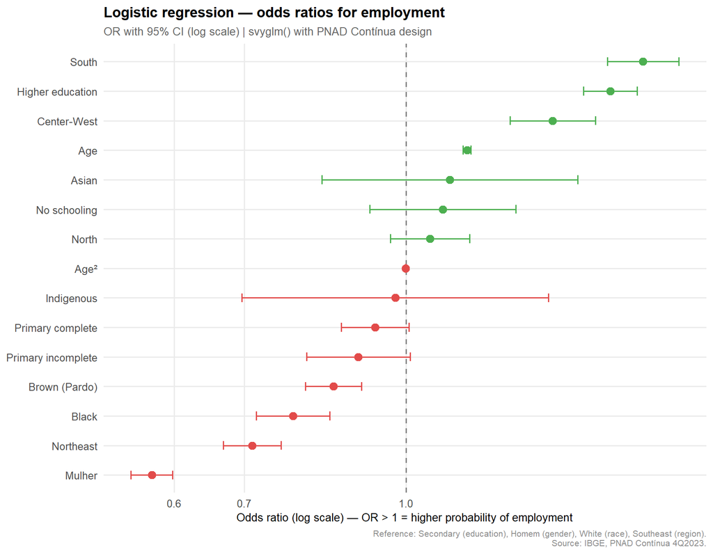

Logistic regression — odds ratios for employment

```r
tidy_logit |>
  mutate(
    direction  = ifelse(estimate > 1, "higher odds", "lower odds"),
    term_clean = term |>
      str_remove("^education|^V2007|^race|^macro_region") |>
      str_replace("age_sq", "Age²") |>
      str_replace("^age$", "Age")
  ) |>
  ggplot(aes(x = estimate, y = reorder(term_clean, estimate), color = direction)) +
  geom_vline(xintercept = 1, linetype = "dashed", color = "grey50") +
  geom_point(size = 3) +
  geom_errorbar(aes(xmin = conf.low, xmax = conf.high),
                width = 0.3, orientation = "y") +
  scale_x_log10() +
  scale_color_manual(
    values = c("higher odds" = unname(PALETTE["green"]),
               "lower odds"  = unname(PALETTE["accent"])),
    guide  = "none"
  ) +
  labs(
    title    = "Logistic regression — odds ratios for employment",
    subtitle = "OR with 95% CI (log scale) | svyglm() with PNAD Contínua design",
    x = "Odds ratio (log scale) — OR > 1 = higher probability of employment",
    y = NULL,
    caption  = "Reference: Secondary (education), Homem (gender), White (race), Southeast (region).\nSource: IBGE, PNAD Contínua 4Q2023."
  ) +
  theme_pnadc()
```

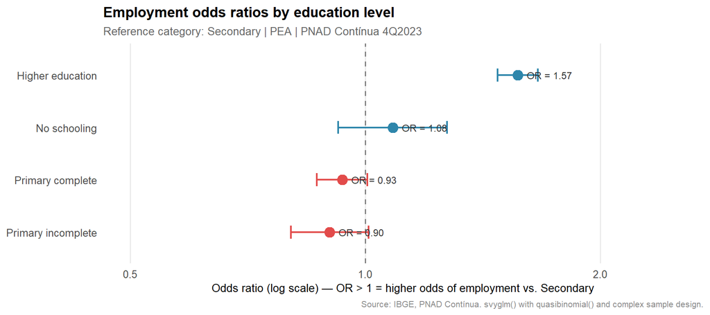

Employment odds ratios by education level

```r
tidy_logit |>
  filter(str_detect(term, "^education")) |>
  mutate(
    term_clean = str_remove(term, "^education"),
    term_clean = factor(term_clean,
      levels = c("No schooling","Primary incomplete","Primary complete","Higher education")),
    direction  = ifelse(estimate > 1, "higher odds", "lower odds")
  ) |>
  ggplot(aes(x = estimate, y = reorder(term_clean, estimate), color = direction)) +
  geom_vline(xintercept = 1, linetype = "dashed", color = "grey50") +
  geom_point(size = 4) +
  geom_errorbar(aes(xmin = conf.low, xmax = conf.high),
                width = 0.25, orientation = "y", linewidth = 0.8) +
  geom_text(aes(label = sprintf("OR = %.2f", estimate)),
            hjust = -0.2, size = 3.2, color = "grey20") +
  scale_x_log10(limits = c(0.5, 2.5)) +
  scale_color_manual(
    values = c("higher odds" = unname(PALETTE["main"]),
               "lower odds"  = unname(PALETTE["accent"])),
    guide  = "none"
  ) +
  labs(
    title    = "Employment odds ratios by education level",
    subtitle = "Reference category: Secondary | PEA | PNAD Contínua 4Q2023",
    x = "Odds ratio (log scale) — OR > 1 = higher odds of employment vs. Secondary",
    y = NULL,
    caption  = "Source: IBGE, PNAD Contínua. svyglm() with quasibinomial() and complex sample design."
  ) +
  theme_pnadc() +
  theme(panel.grid.major.y = element_blank())
```

**Key findings:**

- **Women** in the labor force have **43% lower odds** of being employed than men (OR = 0.57), the strongest predictor in the model
- Workers with **higher education** have **57% higher odds** of employment than those with secondary education (OR = 1.57)
- **Black** workers have 22% lower odds of employment than White workers (OR = 0.78)
- The **South** shows substantially higher employment odds than the Southeast reference (OR = 1.68)

## 8. Summary

This analysis demonstrates a complete survey data workflow using PNAD Contínua:

| Pipeline | Key demonstration |
| --- | --- |
| Descriptive | Data download, label-based recoding, ggplot2 visualization |
| Survey weights | Correct weighted estimation, DEFF, `svyby()`, `srvyr` |
| Regression | `svyglm()` for OLS and logistic models with valid inference |

*Data: IBGE, PNAD Contínua 4Q2023. Analysis: Teresa De Bastiani.*